# Figure S4 — Covariate robustness of the cerebellar prematurity findings

Single-covariate sensitivity analyses (Figure S4A/B) and their tabulated values (Tables S2 and S4)

2026-09-03 10:54:28

# Overview

Each clinical covariate is added to the base model **one at a time**; we ask whether the finding of interest survives that single adjustment. This report is the code + data provenance for two supplementary outputs that share the same source (single-covariate model summaries):

- **Figure S4A / Table S2** — the gestational-age (GA) effect on term-equivalent cerebellar MRI volume (mm³ per week) under each single-covariate adjustment. Panel A plots it as a forest; Table S2 tabulates the same β, 95% CI, *P* and *n*.
- **Figure S4B / Table S4** — GA and cerebellar volume as predictors of neurodevelopmental delay (motor / cognitive / language). Panel B plots the *P*-value grids; Table S4 tabulates the GA→delay *P*, the cerebellar-volume→delay odds ratio (95% CI) and its Wald *P*.

In the figures, *pink* = association retained (`P < 0.05`), *grey* = not retained after adjustment. Panels are exported as **separate files** (never combined in code) so they can be arranged by hand. The tables below are rendered **inline from the same data** — no Word/Excel file is produced here (the submission copies of Tables S2/S4 are maintained separately and are not written by this report).

# Load model summaries

```r
gv   <- function(m, k) if (k %in% names(m)) unname(m[[k]]) else NA_real_
pcol <- function(d, col) setNames(d[[col]], norm(d$Covariate))

# GA -> cerebellar volume (one row per covariate): beta / CI / P / N
vol <- rd("1 CerebVol vs GA.csv"); vol$key <- norm(vol$Covariate)

# GA -> neurodevelopmental delay (LRT P per domain) and volume -> delay (Wald P per domain)
P <- list(
  ga_mot = pcol(rd("2 Motor_Delay vs GA.csv"),     "P.Value"),
  ga_cog = pcol(rd("2 Cognitive_Delay vs GA.csv"), "P.Value"),
  ga_lan = pcol(rd("2 Language_Delay vs GA.csv"),  "P.Value"),
  cv_mot = pcol(rd("3 Motor_Delay vs CerebVol_k.csv"),     "P.CerebVol_k"),
  cv_cog = pcol(rd("3 Cognitive_Delay vs CerebVol_k.csv"), "P.CerebVol_k"),
  cv_lan = pcol(rd("3 Language_Delay vs CerebVol_k.csv"),  "P.CerebVol_k"))

# master frame used by the figure panels (GA->volume + delay p-values, keyed by covariate)
master <- vol %>%
  transmute(raw_label = Covariate, key = norm(Covariate),
            beta = Beta.GA, lo = CI.Low, hi = CI.High, P_volume = P.GA, N = N) %>%
  rowwise() %>%
  mutate(GA_motor = gv(P$ga_mot, key), GA_cog = gv(P$ga_cog, key), GA_lang = gv(P$ga_lan, key),
         CV_motor = gv(P$cv_mot, key), CV_cog = gv(P$cv_cog, key), CV_lang = gv(P$cv_lan, key)) %>%
  ungroup()
```

# Curated covariate set (Figure S4)

```r
CURATED <- tribble(
  ~display,                        ~source,
  "Maternal delivery indication",  "Indication [Spont/Maternal/Unk]",
  "Surgical NEC",                  "NEC Surgical [Y/N/Unk]",
  "Cumulative burden of BPD",      "BPD_score",
  "Cumulative burden of sepsis",   "Sepsis_score",
  "Magnesium sulfate",             "Magnesium sulfate [Y/N/Unk]",
  "Caffeine",                      "Caffeine [Y/N/Unk]",
  "Glycemic control",              "Glucose TIR",
  "Cumulative procedural pain",    "PIPP (cumulative)") %>%
  mutate(key = norm(source), display = factor(display, levels = display))
```

# Figure S4A — GA → cerebellar volume (forest)

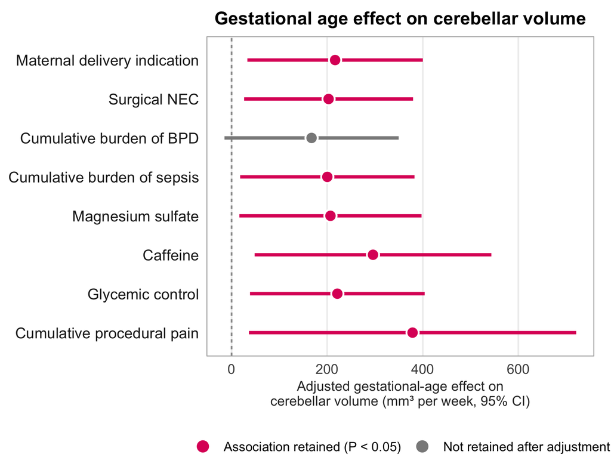

```r
forest_df <- CURATED %>% left_join(master, by = "key") %>%
  mutate(row = factor(display, levels = rev(levels(display))),
         status = factor(ifelse(P_volume < ALPHA, LVL[1], LVL[2]), levels = LVL))

pA <- ggplot(forest_df, aes(y = row)) +
  geom_vline(xintercept = 0, linetype = "22", colour = "#9A9A9A") +
  geom_linerange(aes(xmin = lo, xmax = hi, colour = status), linewidth = 1.1,
                 show.legend = FALSE) +
  geom_point(aes(x = beta, fill = status), shape = 21, size = 3.4,
             colour = "white", stroke = 0.9) +
  scale_colour_manual(values = c(COL_RETAIN_PT, COL_NOTRETAIN) %>% setNames(LVL),
                      drop = FALSE, guide = "none") +
  scale_fill_manual(values = c(COL_RETAIN_PT, COL_NOTRETAIN) %>% setNames(LVL),
                    breaks = LVL, limits = LVL, drop = FALSE, name = NULL) +
  scale_x_continuous(breaks = c(0, 200, 400, 600)) +
  guides(fill = guide_legend(nrow = 1,
         override.aes = list(shape = 21, size = 4, colour = "white"))) +
  labs(title = "Gestational age effect on cerebellar volume",
       x = "Adjusted gestational-age effect on\ncerebellar volume (mm³ per week, 95% CI)",
       y = NULL) +
  coord_cartesian(clip = "off") +
  theme_minimal(base_size = 12) +
  theme(panel.grid.major.y = element_blank(), panel.grid.minor = element_blank(),
        panel.grid.major.x = element_line(colour = "#EFEFEF"),
        panel.border = element_rect(colour = "#B0B0B0", fill = NA, linewidth = 0.3),
        plot.title = element_text(face = "bold", size = 12.5, hjust = 0.5),
        axis.text.y = element_text(colour = "#222222", size = 10.5),
        axis.title.x = element_text(size = 9.5, colour = "#333333"),
        legend.position = "bottom", legend.text = element_text(size = 9),
        plot.margin = margin(t = 8, r = 12, b = 6, l = 6))
ggsave("Figure_S4A_Forest_GA_Volume.pdf", pA, width = 5.9, height = 4.6, device = cairo_pdf, bg = "white")
pA
```

# Figure S4B — p-value grids

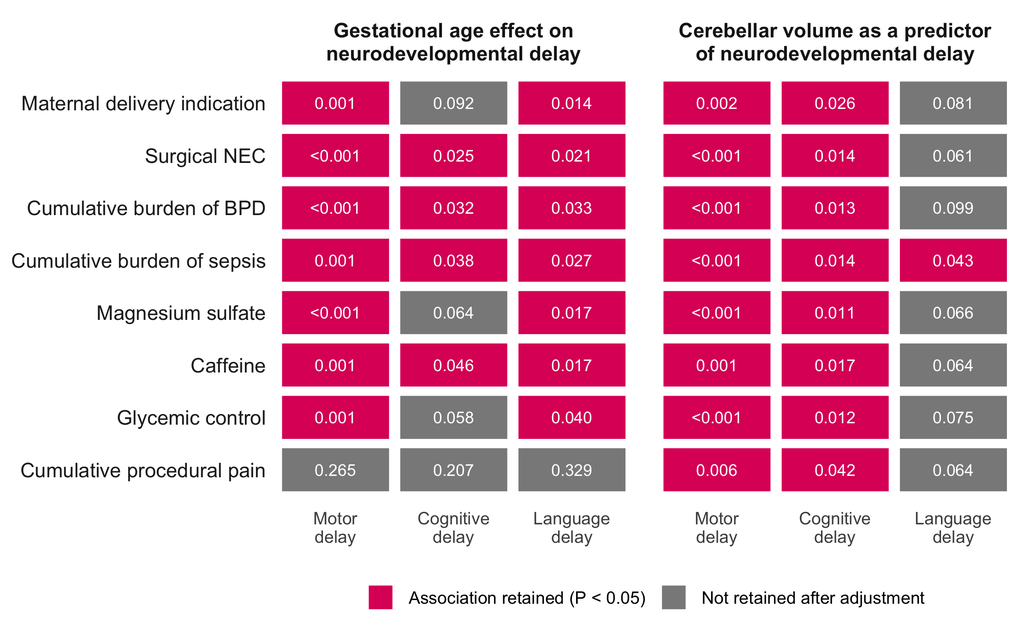

```r
grid_df <- CURATED %>% left_join(master, by = "key") %>%
  transmute(display,
            `Gestational age.Motor` = GA_motor, `Gestational age.Cognitive` = GA_cog,
            `Gestational age.Language` = GA_lang,
            `Cerebellar volume.Motor` = CV_motor, `Cerebellar volume.Cognitive` = CV_cog,
            `Cerebellar volume.Language` = CV_lang) %>%
  pivot_longer(-display, names_to = c("block", "domain"), names_sep = "\\.", values_to = "p") %>%
  mutate(row = factor(display, levels = rev(levels(CURATED$display))),
         block = factor(block, levels = c("Gestational age", "Cerebellar volume")),
         domain = factor(domain, levels = c("Motor", "Cognitive", "Language")),
         sig = !is.na(p) & p < ALPHA,
         status = factor(ifelse(sig, LVL[1], LVL[2]), levels = LVL),
         label = ifelse(is.na(p), "—", ifelse(p < 0.001, "<0.001", sprintf("%.3f", p))))

blk_lab <- as_labeller(c(
  `Gestational age` = "Gestational age effect on\nneurodevelopmental delay",
  `Cerebellar volume` = "Cerebellar volume as a predictor\nof neurodevelopmental delay"))

pB <- ggplot(grid_df, aes(domain, row, fill = status)) +
  geom_tile(colour = "white", linewidth = 1.0, width = 0.94, height = 0.9) +
  geom_text(aes(label = label), colour = "white", size = 3) +
  facet_grid(~ block, labeller = blk_lab) +
  scale_fill_manual(values = c(COL_RETAIN_TILE, COL_NOTRETAIN) %>% setNames(LVL),
                    breaks = LVL, limits = LVL, name = NULL) +
  scale_x_discrete(labels = c(Motor = "Motor\ndelay", Cognitive = "Cognitive\ndelay",
                              Language = "Language\ndelay"),
                   expand = expansion(add = 0.5)) +
  labs(x = NULL, y = NULL) +
  theme_minimal(base_size = 12) +
  theme(panel.grid = element_blank(),
        axis.text.y = element_text(colour = "#222222", size = 10.5),
        axis.text.x = element_text(size = 9, lineheight = 0.9),
        panel.spacing.x = unit(14, "pt"),
        strip.text = element_text(face = "bold", size = 10.5, lineheight = 0.95),
        legend.position = "bottom", legend.text = element_text(size = 9))
ggsave("Figure_S4B_Pvalue_Grids.pdf", pB, width = 7.4, height = 4.6, device = cairo_pdf, bg = "white")
pB
```

# Table S2 — GA effect on cerebellar volume, adjusted for individual clinical factors

Rendered inline from the same model summaries used by Figure S4A (values match the submitted Table S2).

Table S2. Gestational age effect on term-equivalent age cerebellar volume after adjustment for individual clinical factors (in vivo cohort).

| Clinical factor adjusted for | GA β (mm³ per week) | 95% CI | P | n |
| --- | --- | --- | --- | --- |
| Maternal delivery indication | 216.6 | 33.0 to 400.2 | 0.021 | 115 |
| Surgical necrotizing enterocolitis (NEC) | 202.9 | 26.2 to 379.7 | 0.025 | 120 |
| Cumulative burden of bronchopulmonary dysplasia (BPD) | 167.3 | -14.9 to 349.6 | 0.072 | 117 |
| Cumulative burden of sepsis | 200.3 | 17.9 to 382.7 | 0.032 | 118 |
| Magnesium sulfate exposure | 206.9 | 16.3 to 397.5 | 0.034 | 120 |
| Caffeine exposure | 295.9 | 48.2 to 543.6 | 0.020 | 120 |
| Glycemic control (glucose time in range, 70–180 mg/dL) | 221.3 | 38.5 to 404.0 | 0.018 | 118 |
| Cumulative procedural pain (PIPP) | 378.7 | 36.3 to 721.1 | 0.031 | 116 |

# Table S4 — GA and cerebellar volume as predictors of neurodevelopmental delay, adjusted

Rendered inline from the same model summaries used by Figure S4B (values match the submitted Table S4).

Table S4. Gestational age and cerebellar volume as predictors of neurodevelopmental delay, adjusted for individual clinical covariates (in vivo cohort).

| Covariate adjusted for | Delay domain | GA → delay, P | Cerebellar volume → delay, OR (95% CI) | Wald P |
| --- | --- | --- | --- | --- |
| Delivery indication (spontaneous vs maternal) | Motor | 0.001 | 0.81 (0.71, 0.92) | 0.002 |
|  | Cognitive | 0.092 | 0.87 (0.77, 0.98) | 0.026 |
|  | Language | 0.014 | 0.90 (0.80, 1.01) | 0.081 |
| Surgical necrotizing enterocolitis | Motor | 0.000 | 0.80 (0.70, 0.91) | <0.001 |
|  | Cognitive | 0.025 | 0.86 (0.76, 0.97) | 0.014 |
|  | Language | 0.021 | 0.90 (0.80, 1.00) | 0.061 |
| Sepsis burden | Motor | 0.001 | 0.79 (0.69, 0.91) | <0.001 |
|  | Cognitive | 0.038 | 0.86 (0.76, 0.97) | 0.014 |
|  | Language | 0.027 | 0.89 (0.79, 1.00) | 0.043 |
| Bronchopulmonary dysplasia burden | Motor | 0.001 | 0.79 (0.68, 0.91) | <0.001 |
|  | Cognitive | 0.032 | 0.86 (0.76, 0.97) | 0.013 |
|  | Language | 0.033 | 0.90 (0.80, 1.02) | 0.099 |
| Glycemic control (glucose time-in-range) | Motor | 0.001 | 0.79 (0.69, 0.91) | <0.001 |
|  | Cognitive | 0.058 | 0.86 (0.76, 0.97) | 0.012 |
|  | Language | 0.040 | 0.90 (0.80, 1.01) | 0.075 |
| Cumulative procedural pain (PIPP) | Motor | 0.265 | 0.60 (0.42, 0.87) | 0.006 |
|  | Cognitive | 0.207 | 0.79 (0.64, 0.99) | 0.042 |
|  | Language | 0.329 | 0.83 (0.68, 1.01) | 0.064 |
| Magnesium sulfate | Motor | 0.000 | 0.79 (0.69, 0.90) | <0.001 |
|  | Cognitive | 0.064 | 0.85 (0.76, 0.96) | 0.011 |
|  | Language | 0.017 | 0.90 (0.80, 1.01) | 0.066 |
| Caffeine | Motor | 0.001 | 0.80 (0.70, 0.92) | 0.001 |
|  | Cognitive | 0.046 | 0.86 (0.76, 0.97) | 0.017 |
|  | Language | 0.017 | 0.89 (0.80, 1.01) | 0.064 |